# Activity Project

Cindy

2025-01-21

## Loading and preprocessing the data

```r
setwd("/Users/cindyliu/Desktop/Coursera")
activity<-read.csv("activity.csv")
head(activity)
```

```
##   steps       date interval
## 1    NA 2012-10-01        0
## 2    NA 2012-10-01        5
## 3    NA 2012-10-01       10
## 4    NA 2012-10-01       15
## 5    NA 2012-10-01       20
## 6    NA 2012-10-01       25
```

```r
library(ggplot2)
```

The data consists of three columns:

1. steps: Number of steps taking in a 5-minute interval (missing values are coded as NA.
2. date: The date on which the measurement was taken in YYYY-MM-DD format.
3. interval: Identifier for the 5-minute interval in which measurement was taken.

## What is mean total number of steps taken per day?

1. Calculate the total number of steps taken per day

```r
daystep<- aggregate(activity$steps, by=list(Day=activity$date), FUN=sum)
```

2. Histogram of the total number of steps taken each day

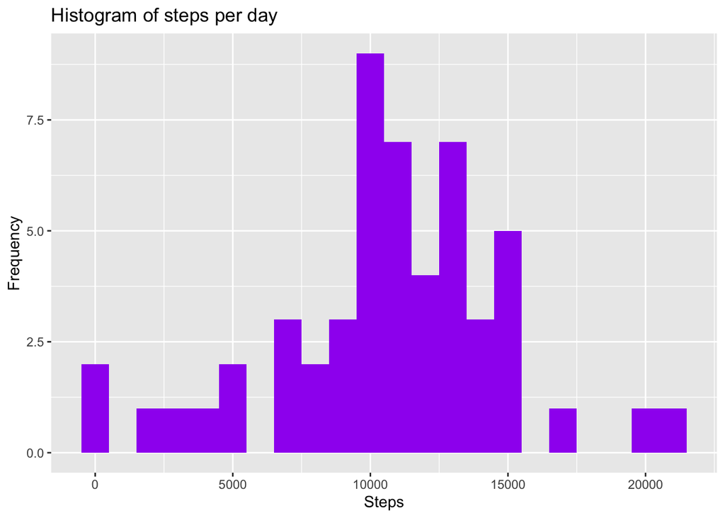

```r
ggplot(daystep, aes(x)) +
    geom_histogram(fill = "purple", binwidth = 1000) +
    labs(title = "Histogram of steps per day", x = "Steps", y = "Frequency")
```

3. Mean and median number of steps taken each day

```r
mean(daystep$x, na.rm= TRUE)
```

```
## [1] 10766.19
```

```r
median(daystep$x, na.rm=TRUE)
```

```
## [1] 10765
```

## What is the average daily activity pattern?

1. Make a time series plot of the 5-minute interval (x-axis) and the average number of steps taken, averaged across all days (y-axis)

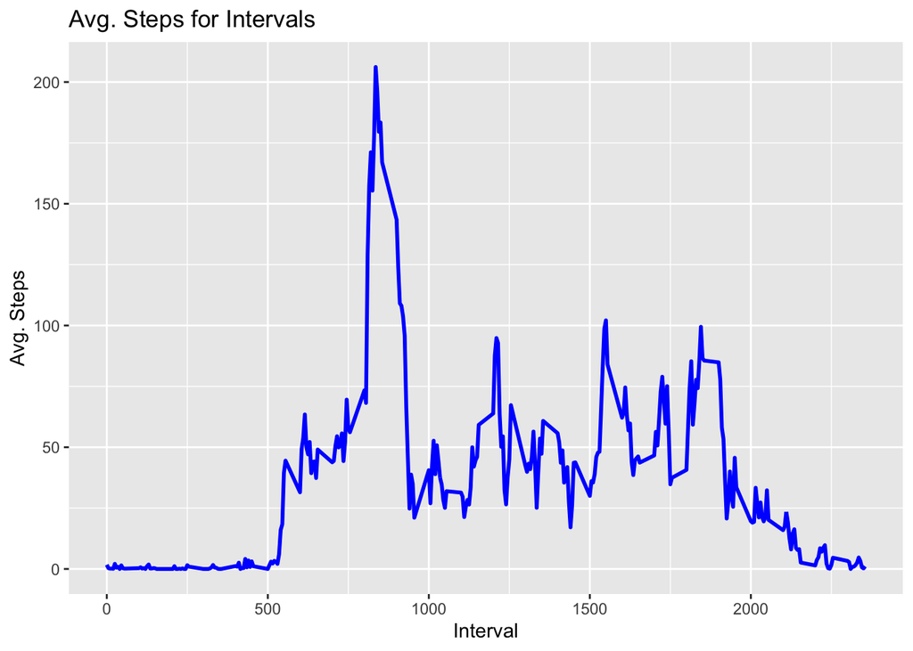

```r
removeNA<- subset(activity, is.na(steps)==FALSE)
intsteps <-aggregate(removeNA$steps, by=list(Interval=removeNA$interval), FUN=mean)
colnames(intsteps)<- c("Interval", "AvgStep")
ggplot(intsteps) +
  geom_line(aes(x = Interval , y = AvgStep),color="blue",linewidth=1)+
  labs(title = "Avg. Steps for Intervals", x = "Interval", y = "Avg. Steps")
```

2. Which 5-minute interval, on average across all the days in the dataset, contains the maximum number of steps?

```r
intsteps[which(intsteps$AvgStep==max(intsteps$AvgStep)),1]
```

```
## [1] 835
```

## Imputing missing values

The total number of missing values is 2304 rows.

```r
nrow(subset(activity, is.na(steps)==TRUE))
```

```
## [1] 2304
```

I will replace the missing values with the mean of the steps in the interval. The updated data is shown below.

```r
activityNew<- activity
for(i in 1:nrow(activityNew)){
    if(is.na(activityNew[i,]$steps)){
        row<- which(intsteps$Interval==activityNew[i,]$interval)
        activityNew[i,]$steps<-intsteps[row,]$AvgStep
    }
}
head(activityNew)
```

```
##       steps       date interval
## 1 1.7169811 2012-10-01        0
## 2 0.3396226 2012-10-01        5
## 3 0.1320755 2012-10-01       10
## 4 0.1509434 2012-10-01       15
## 5 0.0754717 2012-10-01       20
## 6 2.0943396 2012-10-01       25
```

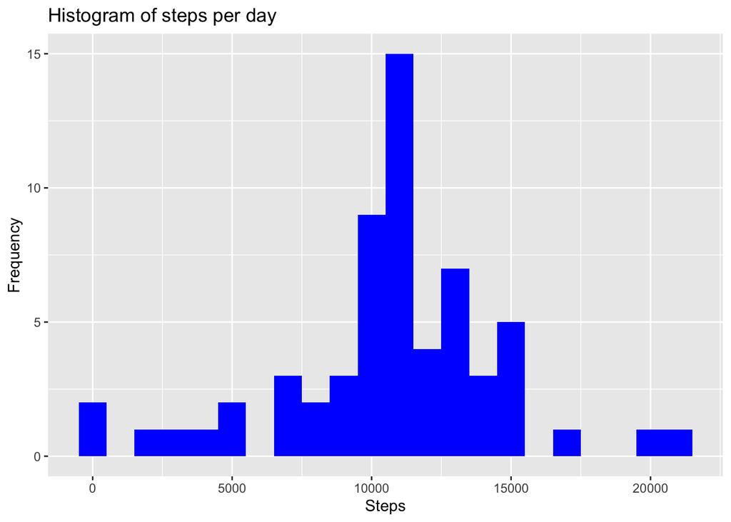

```r
daystepNew<- aggregate(activityNew$steps, by=list(Day=activityNew$date), FUN=sum)
ggplot(daystepNew, aes(x)) +
    geom_histogram(fill = "blue", binwidth = 1000) +
    labs(title = "Histogram of steps per day", x = "Steps", y = "Frequency")
```

```r
mean(daystepNew$x, na.rm= TRUE)
```

```
## [1] 10766.19
```

```r
median(daystepNew$x, na.rm=TRUE)
```

```
## [1] 10766.19
```

## Are there differences in activity patterns between weekdays and weekends?

```r
activityNew$date <- as.Date(activityNew$date)
activityNew$day <- weekdays(activityNew$date)
for (i in 1:nrow(activityNew)) {
    if (activityNew[i,]$day=="Saturday"|activityNew[i,]$day=="Sunday") {
        activityNew[i,]$day<-"weekend"
    }
    else{
        activityNew[i,]$day<-"weekday"
    }
}
```

```r
 weekstep<- activityNew[activityNew$day=="weekday",]
 weekendstep<- activityNew[activityNew$day=="weekend",]
 week<-aggregate(weekstep$steps, by=list(Interval=weekstep$interval), FUN=sum)
 weekend<-aggregate(weekendstep$steps, by=list(Interval=weekendstep$interval), FUN=sum)
 colnames(week)<-colnames(weekend)<- c("Interval", "sum")

p2<- ggplot(week) +
 geom_line(aes(x = Interval , y = sum),color="purple",linewidth=1)
 labs(title = "Average Interval Steps of weekdays", x = "Interval", y = "Average. of Steps")
```

[output not shown]

[figure not shown]

```r
p1<- ggplot(weekend) +
geom_line(aes(x = Interval , y = sum),color="blue",linewidth=1)+
labs(title = "Average Interval Steps for weekends", x = "Interval", y = "Average. Steps")

library(gridExtra)
grid.arrange(p1, p2, ncol = 1)
```